# Email Campaign

Jacob Igel & Samuel Vaughan

Last complied on April 20, 2023

We are interested in designing a campaign that will maximize the response rate. We are very sure, based on experience, that there are four drivers for this process. However, we have no idea how those factors might interact. The factors are shown below.

[figure not shown]

1. What type of design would you recommend for this situation?
- 2^k factorial design
2. Construct that design below. Use the `FrF2` package.

```r
library(FrF2)
d<-FrF2(nruns=16, nfactors=4, randomize = TRUE)
d
```

```
##     A  B  C  D
## 1  -1 -1 -1  1
## 2   1  1  1  1
## 3   1 -1  1 -1
## 4   1  1 -1  1
## 5   1 -1 -1 -1
## 6  -1  1 -1 -1
## 7  -1 -1  1  1
## 8   1 -1 -1  1
## 9  -1 -1 -1 -1
## 10 -1  1  1  1
## 11 -1  1 -1  1
## 12  1  1 -1 -1
## 13 -1 -1  1 -1
## 14 -1  1  1 -1
## 15  1  1  1 -1
## 16  1 -1  1  1
## class=design, type= full factorial
```

3. That was just for fun. Now read in the file “EmailCampaign.csv”.

```r
df <-read.csv("/Users/jacobigel/Desktop/School/ISA365-A/Datasets/EmailCampaign.csv",stringsAsFactors = TRUE)

head(df)
```

```
##   X  A  B  C  D    y
## 1 1 -1 -1 -1 -1 1.67
## 2 2  1 -1 -1 -1 1.93
## 3 3 -1  1 -1 -1 1.12
## 4 4  1  1 -1 -1 1.39
## 5 5 -1 -1  1 -1 1.95
## 6 6  1 -1  1 -1 1.60
```

4. What is the highest order interaction effect we can estimate with this design?
- 4 way interaction (A, B, C, D)
5. Fit the Saturated model.

```r
reg<-lm(y~A*B*C*D, data=df)
summary(reg)
```

```
##
## Call:
## lm.default(formula = y ~ A * B * C * D, data = df)
##
## Residuals:
## ALL 16 residuals are 0: no residual degrees of freedom!
##
## Coefficients:
##             Estimate Std. Error t value Pr(>|t|)
## (Intercept)  2.02875        NaN     NaN      NaN
## A           -0.12500        NaN     NaN      NaN
## B           -0.15625        NaN     NaN      NaN
## C            0.12375        NaN     NaN      NaN
## D            0.38750        NaN     NaN      NaN
## A:B          0.06500        NaN     NaN      NaN
## A:C         -0.15500        NaN     NaN      NaN
## B:C          0.09125        NaN     NaN      NaN
## A:D         -0.02875        NaN     NaN      NaN
## B:D         -0.01000        NaN     NaN      NaN
## C:D          0.01000        NaN     NaN      NaN
## A:B:C       -0.10750        NaN     NaN      NaN
## A:B:D        0.13875        NaN     NaN      NaN
## A:C:D        0.07375        NaN     NaN      NaN
## B:C:D       -0.03500        NaN     NaN      NaN
## A:B:C:D     -0.03125        NaN     NaN      NaN
##
## Residual standard error: NaN on 0 degrees of freedom
## Multiple R-squared:      1,  Adjusted R-squared:    NaN
## F-statistic:   NaN on 15 and 0 DF,  p-value: NA
```

6. Analyze this design with a half normal plot. What effects look significant? Remember you can change alpha=0.95 to show the labels of all of the effects.

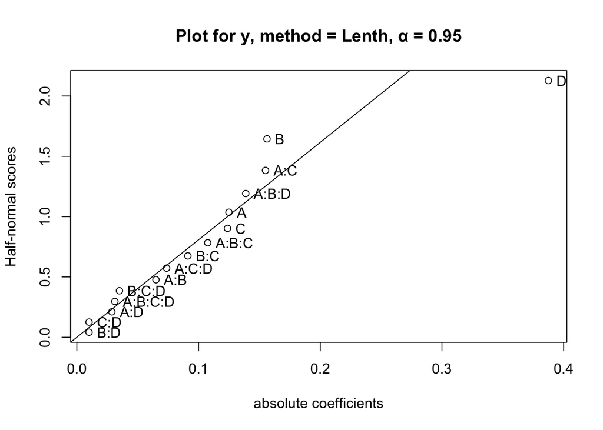

```r
hncoeff<-halfnormal(reg, alpha=0.95)$coef
pse<-ME.Lenth(hncoeff)$PSE
abline(a=0, b=1/pse)
```

* From this plot, we can see that D and B are teh effects that look the most significant.

7. Construct an interaction plot matrix for this experiment. What do you observe?

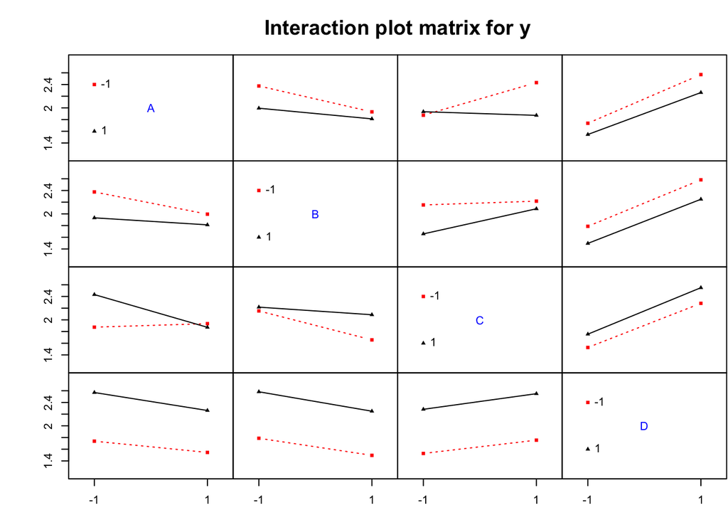

```r
library(FrF2)
IAPlot(reg)
```

* We can see that A and C might have an interesting interaction * Possibly B and C have an interaction, need to do further testing.

8. Fit the model that excludes the 4 way interaction. What happens to the degree of freedom associated with the 4 way interaction?

```r
reg1<-lm(y~A*B*C*D-A:B:C:D, data=df)
summary(reg1)
```

```
##
## Call:
## lm.default(formula = y ~ A * B * C * D - A:B:C:D, data = df)
##
## Residuals:
##        1        2        3        4        5        6        7        8
## -0.03125  0.03125  0.03125 -0.03125  0.03125 -0.03125 -0.03125  0.03125
##        9       10       11       12       13       14       15       16
##  0.03125 -0.03125 -0.03125  0.03125 -0.03125  0.03125  0.03125 -0.03125
##
## Coefficients:
##             Estimate Std. Error t value Pr(>|t|)
## (Intercept)  2.02875    0.03125   64.92  0.00981 **
## A           -0.12500    0.03125   -4.00  0.15596
## B           -0.15625    0.03125   -5.00  0.12567
## C            0.12375    0.03125    3.96  0.15747
## D            0.38750    0.03125   12.40  0.05123 .
## A:B          0.06500    0.03125    2.08  0.28530
## A:C         -0.15500    0.03125   -4.96  0.12665
## B:C          0.09125    0.03125    2.92  0.21005
## A:D         -0.02875    0.03125   -0.92  0.52651
## B:D         -0.01000    0.03125   -0.32  0.80284
## C:D          0.01000    0.03125    0.32  0.80284
## A:B:C       -0.10750    0.03125   -3.44  0.18010
## A:B:D        0.13875    0.03125    4.44  0.14103
## A:C:D        0.07375    0.03125    2.36  0.25515
## B:C:D       -0.03500    0.03125   -1.12  0.46400
## ---
## Signif. codes:  0 '***' 0.001 '**' 0.01 '*' 0.05 '.' 0.1 ' ' 1
##
## Residual standard error: 0.125 on 1 degrees of freedom
## Multiple R-squared:  0.9965, Adjusted R-squared:  0.948
## F-statistic: 20.52 on 14 and 1 DF,  p-value: 0.1715
```

- Without the four way interaction included in this model, there is 1 DF. When we included the four way interaction, there were zero degrees of freedom.
9. Drop the CD interaction effect with one of the largest p-values.

```r
reg2<-lm(y~A*B*C*D-A:B:C:D-C:D, data=df)
summary(reg2)
```

```
##
## Call:
## lm.default(formula = y ~ A * B * C * D - A:B:C:D - C:D, data = df)
##
## Residuals:
##        1        2        3        4        5        6        7        8
## -0.02125  0.04125  0.04125 -0.02125  0.02125 -0.04125 -0.04125  0.02125
##        9       10       11       12       13       14       15       16
##  0.02125 -0.04125 -0.04125  0.02125 -0.02125  0.04125  0.04125 -0.02125
##
## Coefficients:
##             Estimate Std. Error t value Pr(>|t|)
## (Intercept)  2.02875    0.02320  87.443 0.000131 ***
## A           -0.12500    0.02320  -5.388 0.032766 *
## B           -0.15625    0.02320  -6.735 0.021345 *
## C            0.12375    0.02320   5.334 0.033399 *
## D            0.38750    0.02320  16.702 0.003566 **
## A:B          0.06500    0.02320   2.802 0.107288
## A:C         -0.15500    0.02320  -6.681 0.021679 *
## B:C          0.09125    0.02320   3.933 0.058985 .
## A:D         -0.02875    0.02320  -1.239 0.340972
## B:D         -0.01000    0.02320  -0.431 0.708464
## A:B:C       -0.10750    0.02320  -4.633 0.043558 *
## A:B:D        0.13875    0.02320   5.980 0.026840 *
## A:C:D        0.07375    0.02320   3.179 0.086341 .
## B:C:D       -0.03500    0.02320  -1.509 0.270447
## ---
## Signif. codes:  0 '***' 0.001 '**' 0.01 '*' 0.05 '.' 0.1 ' ' 1
##
## Residual standard error: 0.0928 on 2 degrees of freedom
## Multiple R-squared:  0.9962, Adjusted R-squared:  0.9713
## F-statistic: 40.08 on 13 and 2 DF,  p-value: 0.02459
```

10. Drop the interaction effect with the largest p-value again.

```r
reg3<-lm(y~A*B*C*D-A:B:C:D-C:D-B:D, data=df)
summary(reg3)
```

```
##
## Call:
## lm.default(formula = y ~ A * B * C * D - A:B:C:D - C:D - B:D,
##     data = df)
##
## Residuals:
##        1        2        3        4        5        6        7        8
## -0.03125  0.03125  0.05125 -0.01125  0.01125 -0.05125 -0.03125  0.03125
##        9       10       11       12       13       14       15       16
##  0.03125 -0.03125 -0.05125  0.01125 -0.01125  0.05125  0.03125 -0.03125
##
## Coefficients:
##             Estimate Std. Error t value Pr(>|t|)
## (Intercept)  2.02875    0.01980 102.443 2.05e-06 ***
## A           -0.12500    0.01980  -6.312 0.008037 **
## B           -0.15625    0.01980  -7.890 0.004243 **
## C            0.12375    0.01980   6.249 0.008268 **
## D            0.38750    0.01980  19.567 0.000292 ***
## A:B          0.06500    0.01980   3.282 0.046349 *
## A:C         -0.15500    0.01980  -7.827 0.004343 **
## B:C          0.09125    0.01980   4.608 0.019225 *
## A:D         -0.02875    0.01980  -1.452 0.242491
## A:B:C       -0.10750    0.01980  -5.428 0.012269 *
## A:B:D        0.13875    0.01980   7.006 0.005971 **
## A:C:D        0.07375    0.01980   3.724 0.033713 *
## B:C:D       -0.03500    0.01980  -1.767 0.175334
## ---
## Signif. codes:  0 '***' 0.001 '**' 0.01 '*' 0.05 '.' 0.1 ' ' 1
##
## Residual standard error: 0.07921 on 3 degrees of freedom
## Multiple R-squared:  0.9958, Adjusted R-squared:  0.9791
## F-statistic: 59.58 on 12 and 3 DF,  p-value: 0.003129
```

11. Drop the interaction effect with the largest p-value again.

```r
reg4<-lm(y~A*B*C*D-A:B:C:D-C:D-B:D-A:D, data=df)
summary(reg4)
```

```
##
## Call:
## lm.default(formula = y ~ A * B * C * D - A:B:C:D - C:D - B:D -
##     A:D, data = df)
##
## Residuals:
##       1       2       3       4       5       6       7       8       9      10
## -0.0600  0.0600  0.0225  0.0175 -0.0175 -0.0225 -0.0600  0.0600  0.0600 -0.0600
##      11      12      13      14      15      16
## -0.0225 -0.0175  0.0175  0.0225  0.0600 -0.0600
##
## Coefficients:
##             Estimate Std. Error t value Pr(>|t|)
## (Intercept)  2.02875    0.02238  90.658 8.88e-08 ***
## A           -0.12500    0.02238  -5.586  0.00504 **
## B           -0.15625    0.02238  -6.982  0.00221 **
## C            0.12375    0.02238   5.530  0.00522 **
## D            0.38750    0.02238  17.316 6.53e-05 ***
## A:B          0.06500    0.02238   2.905  0.04391 *
## A:C         -0.15500    0.02238  -6.926  0.00228 **
## B:C          0.09125    0.02238   4.078  0.01513 *
## A:B:C       -0.10750    0.02238  -4.804  0.00862 **
## A:B:D        0.13875    0.02238   6.200  0.00344 **
## A:C:D        0.07375    0.02238   3.296  0.03006 *
## B:C:D       -0.03500    0.02238  -1.564  0.19286
## ---
## Signif. codes:  0 '***' 0.001 '**' 0.01 '*' 0.05 '.' 0.1 ' ' 1
##
## Residual standard error: 0.08951 on 4 degrees of freedom
## Multiple R-squared:  0.9929, Adjusted R-squared:  0.9733
## F-statistic: 50.75 on 11 and 4 DF,  p-value: 0.0008856
```

12. Drop the interaction effect with the largest p-value again.

```r
reg5<-lm(y~A*B*C*D-A:B:C:D-C:D-B:D-A:D-B:C:D, data=df)
summary(reg5)
```

```
##
## Call:
## lm.default(formula = y ~ A * B * C * D - A:B:C:D - C:D - B:D -
##     A:D - B:C:D, data = df)
##
## Residuals:
##       1       2       3       4       5       6       7       8       9      10
## -0.0250  0.0950 -0.0125 -0.0175 -0.0525 -0.0575 -0.0250  0.0950  0.0250 -0.0950
##      11      12      13      14      15      16
##  0.0125  0.0175  0.0525  0.0575  0.0250 -0.0950
##
## Coefficients:
##             Estimate Std. Error t value Pr(>|t|)
## (Intercept)  2.02875    0.02541  79.843 5.84e-09 ***
## A           -0.12500    0.02541  -4.919  0.00440 **
## B           -0.15625    0.02541  -6.149  0.00165 **
## C            0.12375    0.02541   4.870  0.00459 **
## D            0.38750    0.02541  15.250 2.20e-05 ***
## A:B          0.06500    0.02541   2.558  0.05076 .
## A:C         -0.15500    0.02541  -6.100  0.00171 **
## B:C          0.09125    0.02541   3.591  0.01569 *
## A:B:C       -0.10750    0.02541  -4.231  0.00824 **
## A:B:D        0.13875    0.02541   5.461  0.00280 **
## A:C:D        0.07375    0.02541   2.902  0.03369 *
## ---
## Signif. codes:  0 '***' 0.001 '**' 0.01 '*' 0.05 '.' 0.1 ' ' 1
##
## Residual standard error: 0.1016 on 5 degrees of freedom
## Multiple R-squared:  0.9885, Adjusted R-squared:  0.9656
## F-statistic: 43.11 on 10 and 5 DF,  p-value: 0.0003195
```

13. Now we have to add in the effects that need to be in the model based on effect heredity. Those are AD and BD.

```r
reg6<-lm(y~A*B*C*D-A:B:C:D-C:D-B:C:D, data=df)
summary(reg6)
```

```
##
## Call:
## lm.default(formula = y ~ A * B * C * D - A:B:C:D - C:D - B:C:D,
##     data = df)
##
## Residuals:
##        1        2        3        4        5        6        7        8
##  0.01375  0.07625  0.00625 -0.05625 -0.01375 -0.07625 -0.00625  0.05625
##        9       10       11       12       13       14       15       16
## -0.01375 -0.07625 -0.00625  0.05625  0.01375  0.07625  0.00625 -0.05625
##
## Coefficients:
##             Estimate Std. Error t value Pr(>|t|)
## (Intercept)  2.02875    0.02770  73.245 5.61e-06 ***
## A           -0.12500    0.02770  -4.513 0.020333 *
## B           -0.15625    0.02770  -5.641 0.011023 *
## C            0.12375    0.02770   4.468 0.020889 *
## D            0.38750    0.02770  13.990 0.000791 ***
## A:B          0.06500    0.02770   2.347 0.100604
## A:C         -0.15500    0.02770  -5.596 0.011273 *
## B:C          0.09125    0.02770   3.294 0.045924 *
## A:D         -0.02875    0.02770  -1.038 0.375596
## B:D         -0.01000    0.02770  -0.361 0.742000
## A:B:C       -0.10750    0.02770  -3.881 0.030301 *
## A:B:D        0.13875    0.02770   5.009 0.015314 *
## A:C:D        0.07375    0.02770   2.663 0.076167 .
## ---
## Signif. codes:  0 '***' 0.001 '**' 0.01 '*' 0.05 '.' 0.1 ' ' 1
##
## Residual standard error: 0.1108 on 3 degrees of freedom
## Multiple R-squared:  0.9918, Adjusted R-squared:  0.9591
## F-statistic: 30.33 on 12 and 3 DF,  p-value: 0.008459
```

14. Check the assumptions. State the assumption you are checking with each plot.

# Check for Normality

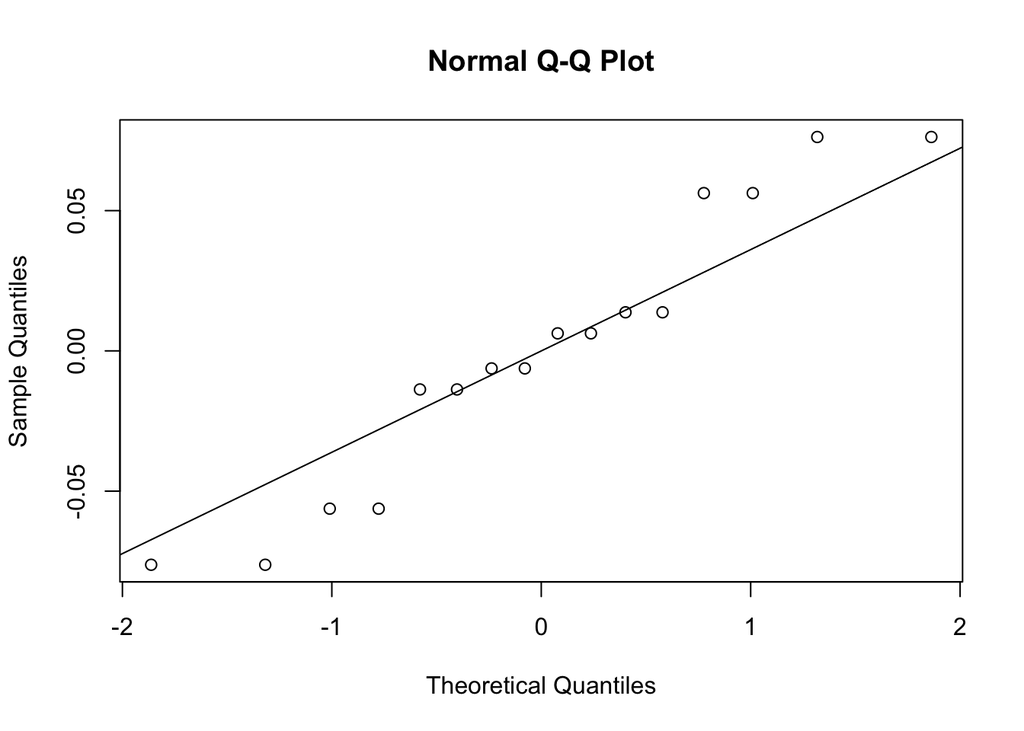

```r
qqnorm(reg6$residuals)
qqline(reg6$residuals)
```

# Checking for a trend (Specifically no trend)

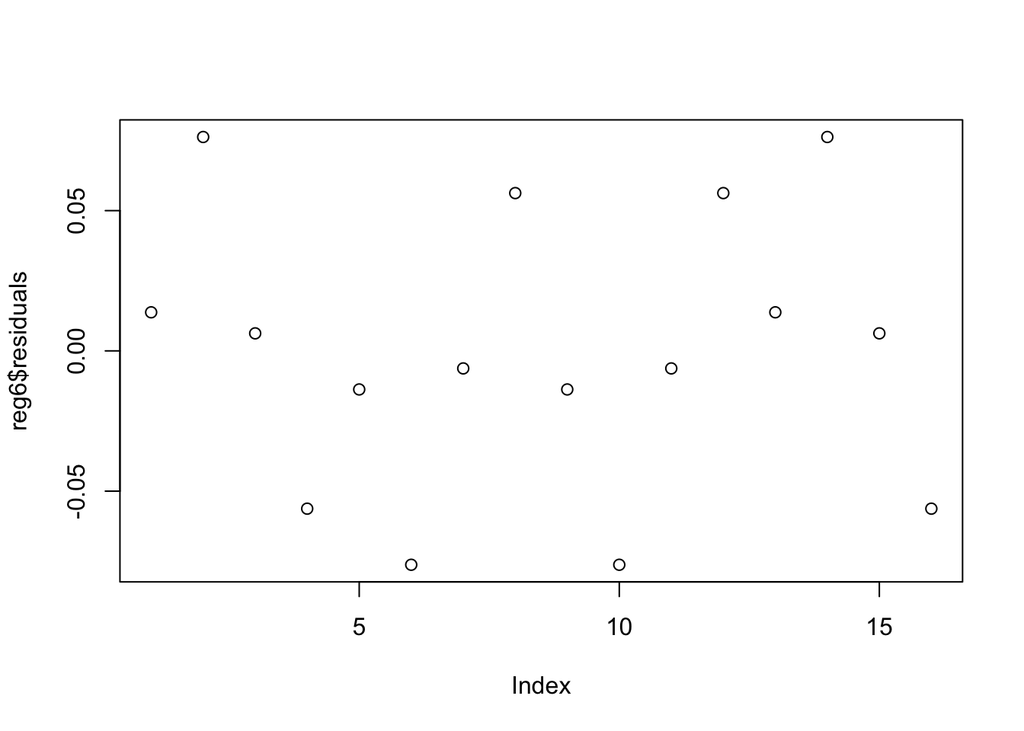

```r
plot(reg6$residuals)
```

# Checking for a pattern (specifically no pattern)

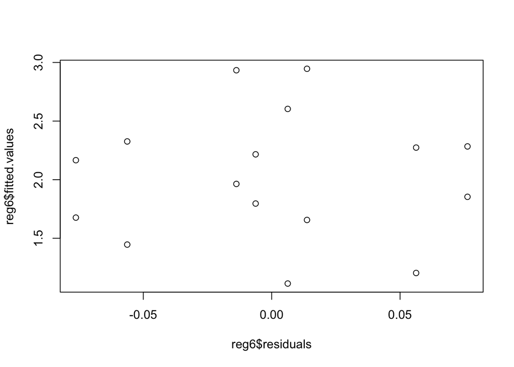

```r
plot(reg6$residuals, reg6$fitted.values)
```

15. Construct the three-way interaction plots for this model. There is no need to look at the two-way interactions since all factors are involved in a three-way interaction.

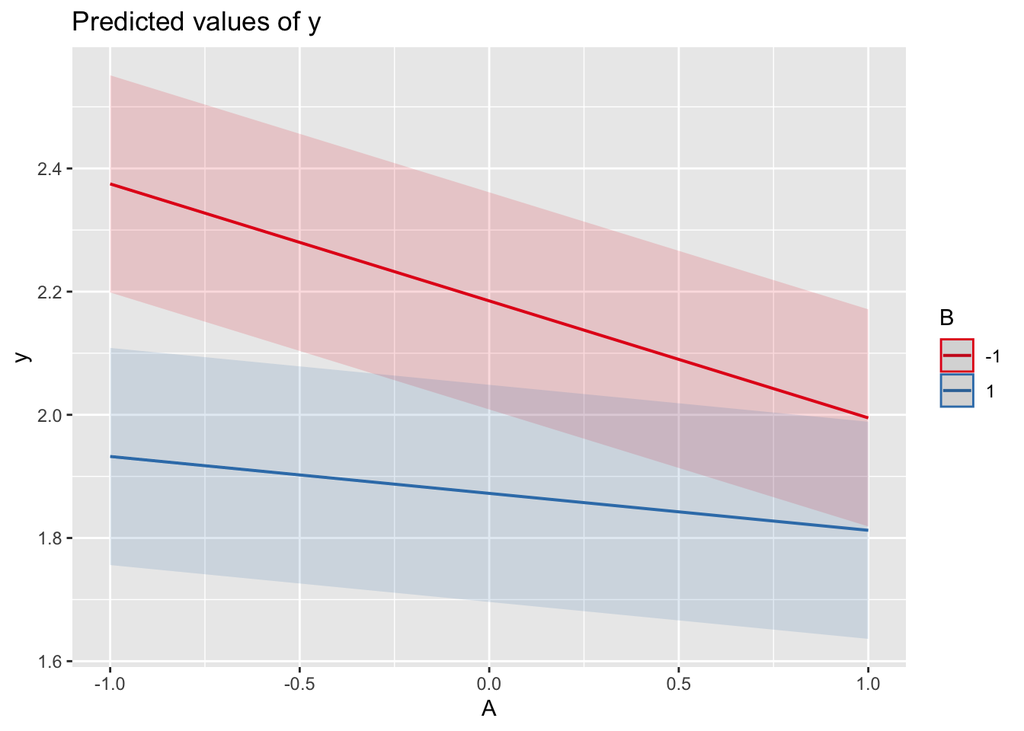

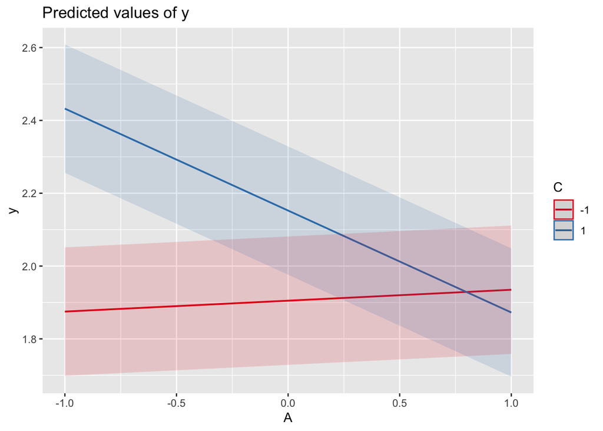

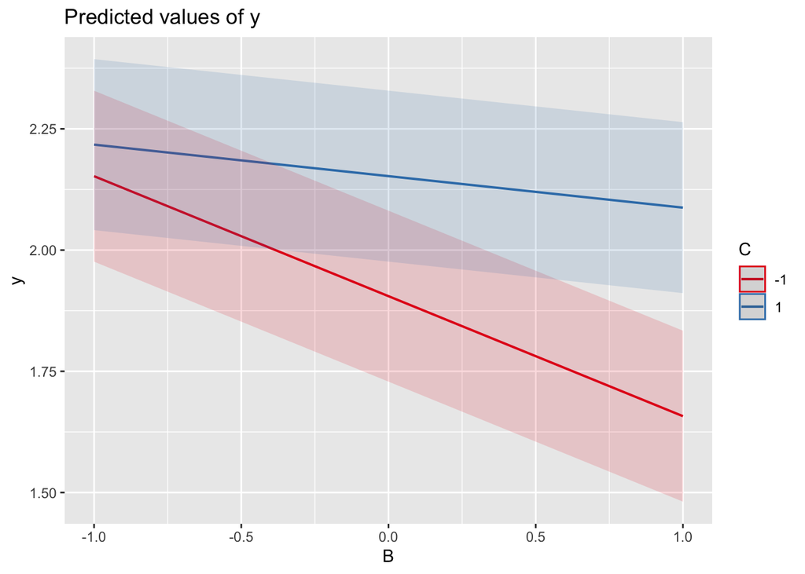

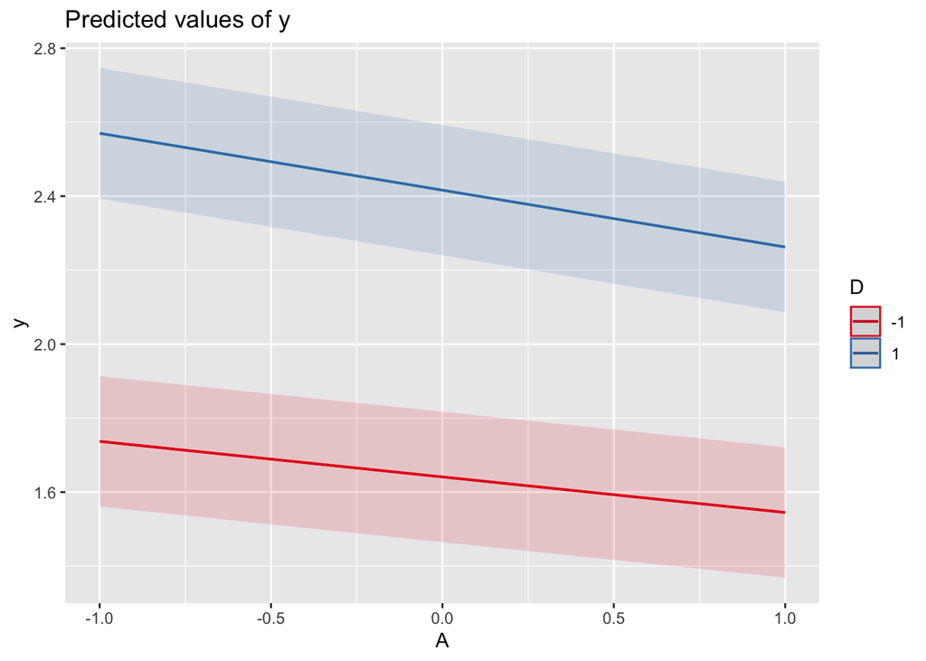

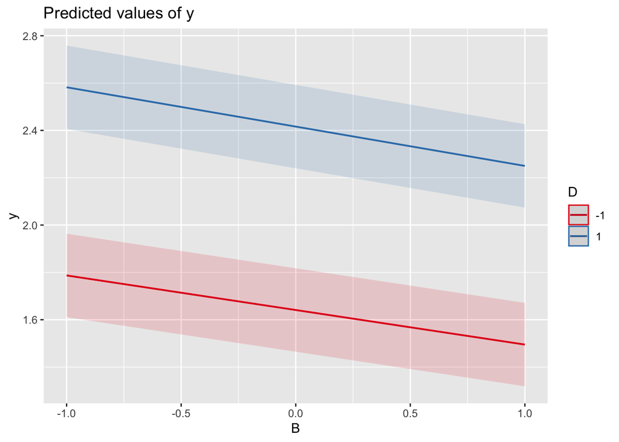

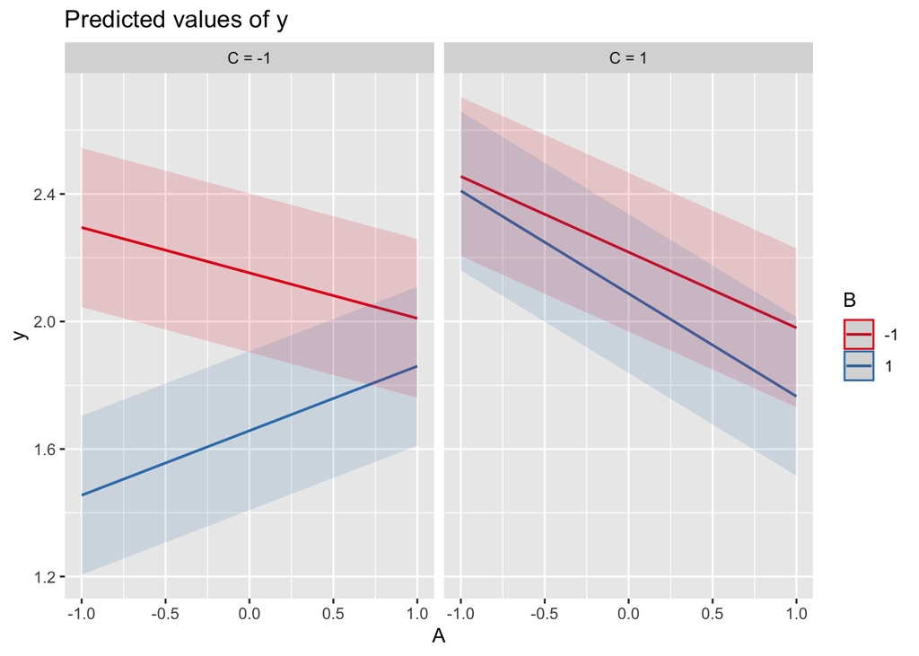

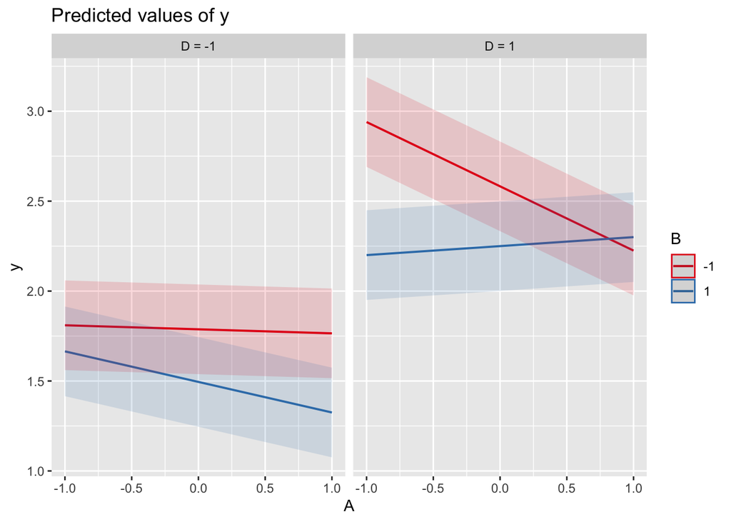

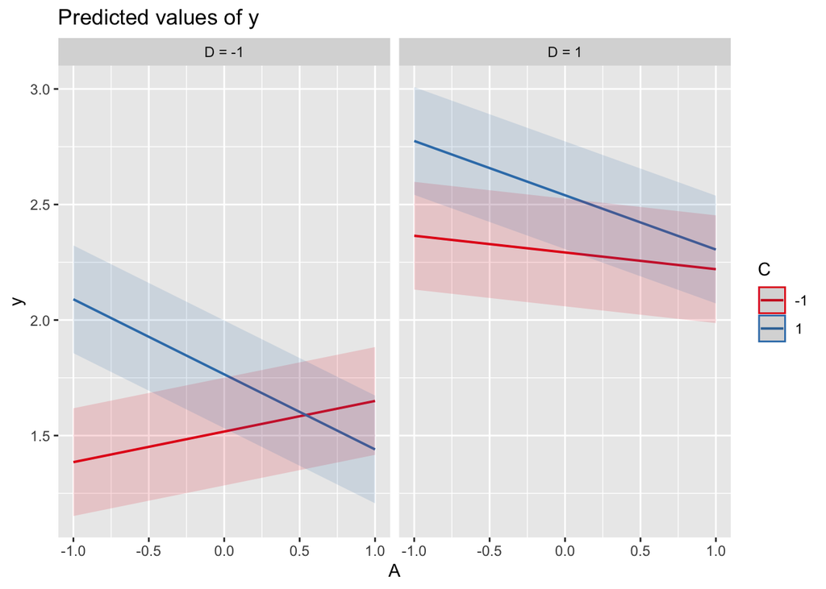

```r
library(sjPlot)
plot_model(reg6, type=c("int"))
```

16. What are the optimal settings? I based these on the three way interaction plots.
- D: +1
- A: -1
- C: +1
- B: -1
17. What is the predicted response for these settings?

```r
optimal<-data.frame(A=-1, B=-1, D=1, C=1)
predict(reg6, optimal, interval="confidence")
```

```
##       fit      lwr      upr
## 1 2.94625 2.628428 3.264072
```